# Case Study 6

**Chance Lister**

library(tidyverse) library(ggplot2)

view(diamonds) ?diamonds

# Distributions of variables

ggplot(data = diamonds, mapping = aes(x = x)) + geom_histogram(fill = “red”, color = “black”) + labs(title = “Length of Diamonds in mm”, x = “length in mm”, y = “quantity”) + theme_grey()

ggplot(data = diamonds, mapping = aes(x = y)) + geom_histogram(fill = “red”, color = “black”) + labs(title = “Width of Diamonds in mm”, x = “width in mm”, y = “quantity”) + theme_grey()

ggplot(data = diamonds, mapping = aes(x = z)) + geom_histogram(fill = “red”, color = “black”) + labs(title = “Depth of Diamonds in mm”, x = “depth in mm”, y = “quantity”) + theme_grey()

# Distribution of Price

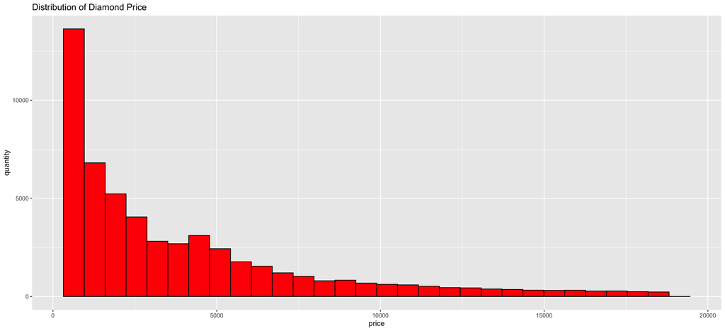

price <- ggplot(data = diamonds, mapping = aes(x = price)) + geom_histogram(fill = ‘red’, color = ‘black’) + labs(title = “Distribution of Diamond Price”, y = “quantity”) + theme_grey()

price

ggsave( filename = “CaseStudy6_graph1.png”, plot = last_plot(), width = 15, units = c(“in”), dpi = 300 )

Data looks as expected for the most part as we see most diamonds below $5000 and quantity decrease as price increases. It is suprising that around the $4000 mark there is a spike in quantity.

# Most Important Variable

## Length

length <- ggplot(diamonds, aes(x = price, y = x)) + geom_point() + geom_abline(slope = 1) + scale_x_continuous(trans = ‘log10’) + labs(title = “Length and Price”, y = “Length of diamonds in mm”) + theme_grey()

length

## Width

width <- ggplot(diamonds, aes(x = price, y = y)) + geom_point() + geom_abline(slope = 1) + scale_x_continuous(trans = ‘log10’) + labs(title = “Width and Price”, y = “Width of diamonds on mm”) + theme_grey()

width

## Depth

depth <- ggplot(diamonds, aes(x = price, y = z)) + geom_point() + geom_abline(slope = 1) + scale_x_continuous(trans = “log10”) + labs(title = “Depth and Price”, y = “Depth of Diamonds in mm”) + theme_grey()

depth

## Depth and Cut

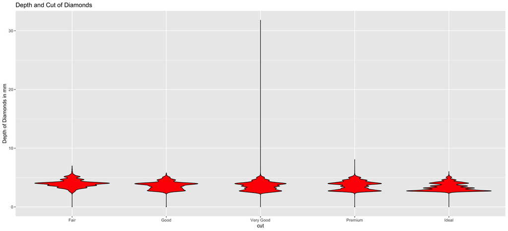

depth_cut <- ggplot(data = diamonds, mapping = aes(x = cut, y = z)) + geom_violin(fill = ‘Red’, color = ‘black’) + labs(title = “Depth and Cut of Diamonds”, y = “Depth of Diamonds in mm”) + theme_grey()

depth_cut

ggsave( filename = “CaseStudy6_graph2.png”, plot = last_plot(), width = 15, units = c(“in”), dpi = 300 )

Most important variable is depth regarding price as price and depth are similar in their rise. In relation to cut depth is correlated as lower quality diamonds may have a larger depth, meaning that lower quality diamonds may be more expensive simply beacause of their depth.

# Carat by Price

diam <- diamonds %>% mutate( type = case_when( price < 2500 ~ ‘<2500’, price < 5000 ~ ‘<5000’, price < 7500 ~ ‘<7500’, price < 10000 ~ ‘<10000’, price < 12500 ~ ‘<12500’, price < 15000 ~ ‘<15000’, price < 17500 ~ ‘<17500’, price < 20000 ~ ‘<20000’, price < 22500 ~ ‘<22500’, TRUE ~ ‘>22500’) )

str = c(“<2500”, “<5000”, “<7500”, “<10000”, “<12500”, “<15000”, “<17500”, “<20000”, “<22500”)

diam$bin1 <- factor(diam$bin1, levels = str)

carat <- ggplot(diam, aes(x = type, y = carat)) + geom_violin(fill = ‘Red’, color = ‘black’) + labs(title = “Carat by Price”, y = “Depth of Diamonds in mm”, x = “Carat of Diamond”) + theme_grey()

carat

# Distribution of large Diamonds versus small Diamonds

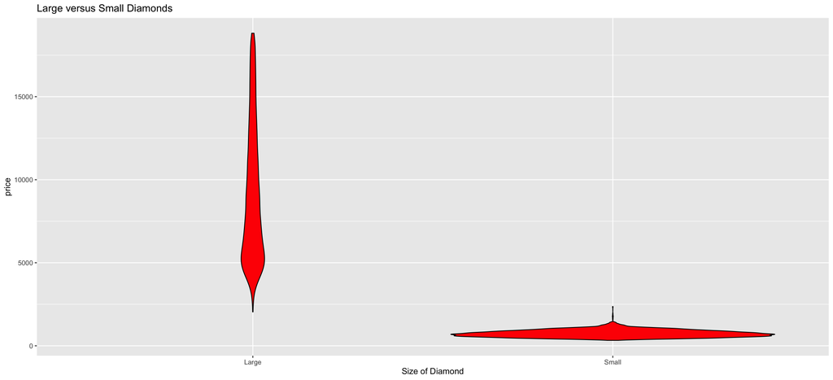

carat_size <- diamonds %>% select(price, carat) %>% mutate( type = case_when( carat <= 0.4 ~ “Small”, carat < 1.04 ~ “Regular”, carat >= 1.04 ~ “Large” ) ) %>% filter(type != ‘Regular’)

carat_size_vis <- ggplot(data = carat_size, mapping = aes(x = type, y = price)) + geom_violin(fill = ‘red’, color = “black”) + labs(title = “Large versus Small Diamonds”, x = “Size of Diamond”) + theme_grey()

carat_size_vis

ggsave( filename = “CaseStudy6_graph3.png”, plot = last_plot(), width = 15, units = c(“in”), dpi = 300 )

Large diamonds have a large distribution of price whereas small diamonds have a fairly even distribution of price. I think it does agree with my expectations as larger diamonds may be rarer or different styles where as smaller diamonds are more than likely similar similar.

# Distribution of Cut, Carat, and Price

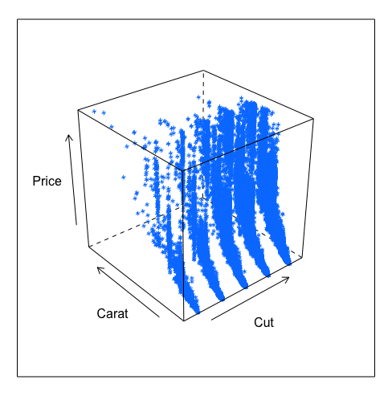

library(lattice)

dist <- cloud(diamonds$price ~ diamonds$cut * diamonds$carat, xlab = “Cut”, ylab = “Carat”, zlab = “Price”)

dist